# A2_YunyiCheng

2024-03-10

## 1. Introduction

In this notebook, we will be performing differential gene expression and preliminary ORA. This notebook was developed by *Yunyi Cheng* and runs under Docker image in the BCB420 GitHub repository.

### 1.1 Recap for Assignment #1

In Assignment #1, we cleaned and normalized a dataset from a recent study on sex-dependent gene expression changes in Parkinson’s disease(PD)<sup>1</sup>. We downloaded the dataset ( GEO id **GSE168496**) and cleaned incorrect values, duplicates, and data points which could not be mapped to HUGO symbols. Furthermore, we reformatted the data frame so that its column name contains metadata information. Afterwards, we normalized it and performed some statistical measures. The final cleaned dataset awaiting further analysis has coverage of 28904 genes and contains 16 samples, with the following conditions:

|  | Ctrl | PD |
| --- | --- | --- |
| Male | 5 | 5 |
| Female | 3 | 3 |

For more information regarding Assignment #1, please consult its [R Notebook](https://github.com/bcb420-2024/Yunyi_Cheng/wiki/Assignment-%231:-Document).

### 1.2 Tasks for Assignment #2

The task is to take the normalized expression data that was created in Assignment #1 and rank the genes according to differential expression. Once the list is ranked we will perform thresholded over-representation analysis to highlight dominant themes in our top set of genes.

## 2. Differential Gene Expression

### 2.1 Load Cleaned Dataset

First, we need to load the cleaned dataset and metadata from Assignment #1.

```r
metadata <- read.csv(file=file.path("../A1/metadataDf.csv"), row.names=1)
cleaned_counts <- read.csv(file=file.path("../A1/a1AggregatedDataDf.csv"), row.names=1)
```

### 2.2 MDS Plot Revisited

In Assignment #1, we performed MDS plotting, let’s revisit it:

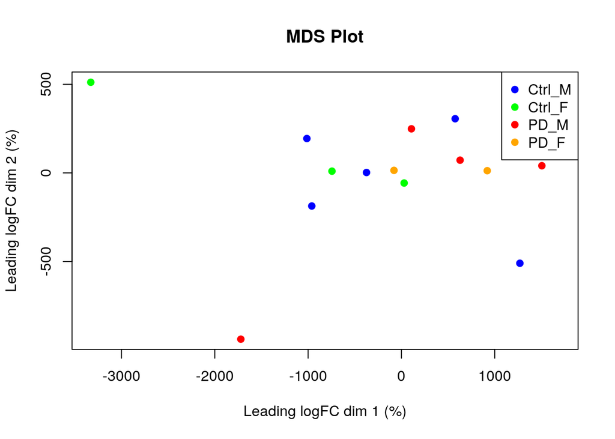

```r
# Create a DGEList object
dge <- DGEList(cleaned_counts)

# Calculate normalization factors to scale the libraries to have the same total counts
dge <- calcNormFactors(dge)

# Obtain normalized counts per million (CPM)
norm_counts <- cpm(dge, log=FALSE, prior.count=0.25)

# Capture group names
group_names <- gsub(".*(Ctrl|PD)_(M|F).*", "\\1_\\2", colnames(norm_counts))

# Create a color palette
group_colors <- c("Ctrl_M" = "blue", "Ctrl_F" = "green",
                  "PD_M" = "red", "PD_F" = "orange")

# Match the colors to the group names
colors <- group_colors[group_names]

# MDS plot using base R plot, suppressing the automatic plot by setting plot=FALSE
mds <- limma::plotMDS(as.matrix(norm_counts), plot=FALSE)
plot(mds$x, mds$y, col=colors, pch=19,
     xlab=paste("Leading logFC dim 1 (", mds$percentVar[1], "%)", sep=""),
     ylab=paste("Leading logFC dim 2 (", mds$percentVar[2], "%)", sep=""))
legend("topright", legend=names(group_colors), col=group_colors, pch=19)

# Add a title
title(main="MDS Plot")
```

### 2.3 P-values Calculation and Multiple Hypothesis Testing

To identify differentially expressed genes, we will perform a linear modeling approach with empirical Bayes moderation of standard errors using `limma`. When setting up the design matrix, I chose to consider disease state and sex so that we are investigating the correlation between sex and PD, which is the reason I chose this dataset.

```r
# Convert necessary columns to factors
metadata$disease.state <- factor(metadata$disease.state)
metadata$gender <- factor(metadata$gender)

# Create a design matrix with disease state and sex
design <- model.matrix(~ disease.state + gender, data=metadata)
# design <- model.matrix(~ disease.state, data=metadata)

# Convert to DGE and estimate dispersion
d = DGEList(counts=norm_counts, group=metadata$disease.state)
d <- estimateDisp(d, design)

# Fit quasi-likelihood model to the counts
fit <- glmQLFit(d, design)

# Significance test
qlf.ctrl_vs_pd <- glmQLFTest(fit, coef=ncol(design))

# Get top hits
qlf_output_hits <- topTags(qlf.ctrl_vs_pd,
sort.by = "PValue",
n = nrow(d))
result <- qlf_output_hits$table

# Print result
num_sig <- length(which(result$PValue < 0.05))
print(paste("Number of differentially expressed genes:", num_sig))
```

```
## [1] "Number of differentially expressed genes: 240"
```

```r
num_FDR_pass <- length(which(result$FDR < 0.1))
print(paste("Number of genes passing FDR correction:", num_FDR_pass))
```

```
## [1] "Number of genes passing FDR correction: 11"
```

### 2.4 Volcano Plot

We will now show the amount of differentially expressed genes using a Volcano plot and highlight genes of interest.

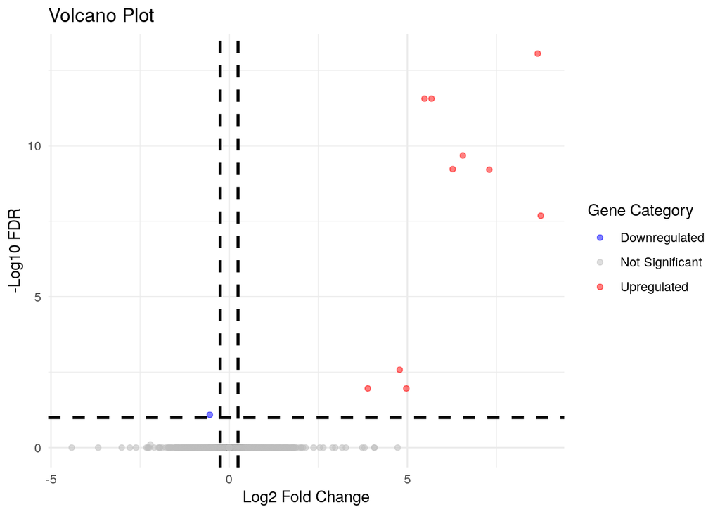

```r
# Distinguish upregulated genes from downregulated genes
result$Category <- with(result,
                        ifelse(FDR < 0.1 & logFC > 0.25, "Upregulated",
                               ifelse(
                                 FDR < 0.1 & logFC < -0.25, "Downregulated", "Not Significant")))

# Create the volcano plot
volcano_plot <- ggplot(result, aes(x = logFC, y = -log10(FDR), color = Category)) +
  geom_point(alpha = 0.5) +
  scale_color_manual(values = c("Not Significant" = "gray", "Upregulated" = "red", "Downregulated" = "blue")) +
  geom_hline(yintercept = (-log10(0.1)), linetype = "dashed", color = "black",
             linewidth = 1) +
  geom_vline(xintercept = c(-0.25, 0.25), linetype = "dashed", color = "black",
             linewidth = 1) +
  labs(title = "Volcano Plot",
       x = "Log2 Fold Change",
       y = "-Log10 FDR",
       color = "Gene Category") +
  theme_minimal() +
  theme(legend.position = "right") +
  guides(color = guide_legend(title = "Gene Category"))

volcano_plot
```

### 2.5 Heatmap of Top Hits

Now we are going to visualize the result by plotting heatmap. Let’s first plot all the significant genes (p-value < 0.05) and include annotations for disease type and sex of the patients.

```r
# Set the row names of metadata to match the column names of norm_counts
rownames(metadata) <- colnames(norm_counts)
```

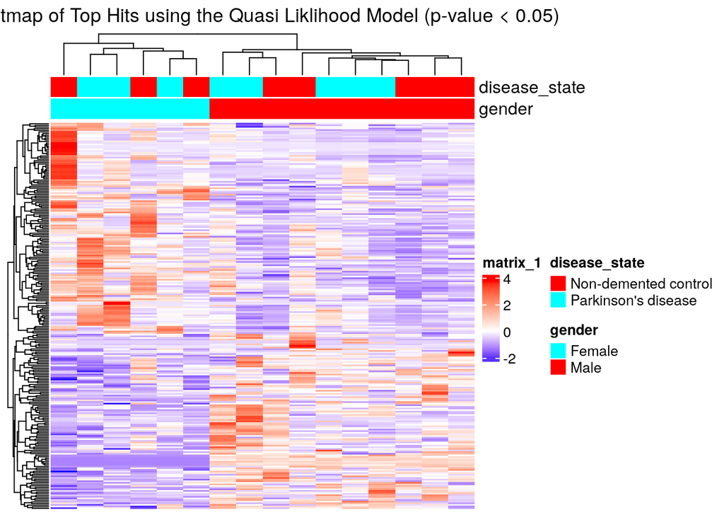

```r
# Select sig genes
sig_genes <- rownames(result)[result$PValue < 0.05]
# Select top genes for heatmap
top_genes <- norm_counts[rownames(norm_counts) %in% rownames(sig_genes), ]

# Ensure metadata matches the order of the 'norm_counts' columns
ordered_metadata <- metadata[match(colnames(top_genes), metadata$GSM), ]

# Select top genes for heatmap
top_hits <- rownames(result)[result$PValue<0.05]

# Scale the heatmap matrix
heatmap_matrix_tophits <- t(
  scale(t(norm_counts[which(rownames(norm_counts)%in% top_hits),])))

# Set the colour scale
if(min(heatmap_matrix_tophits) == 0){
  heatmap_col = colorRamp2(c( 0, max(heatmap_matrix_tophits)), c( "white", "red"))
} else {
  heatmap_col = colorRamp2(c(min(heatmap_matrix_tophits), 0,
                             max(heatmap_matrix_tophits)),
                           c("blue", "white", "red"))
}

# Add annotations

# Define colours - disease state
unique_disease_state <- unique(metadata$disease.state)
unique_diseasestatecolors <- rainbow(n = length(unique_disease_state))
names(unique_diseasestatecolors) <- unique_disease_state

# Define colours - gender
unique_gender <- unique(metadata$gender)
unique_gendercolors <- rainbow(n = length(unique_gender))
names(unique_gendercolors) <- unique_gender

# Annotation pattern
ha_pat <- HeatmapAnnotation(df = data.frame(disease_state = metadata$disease.state,
                                            gender = metadata$gender),
                            col = list(disease_state = unique_diseasestatecolors,
                                       gender = unique_gendercolors),
                            show_legend = TRUE)

# Plot the heatmap
pval_heatmap_an <- Heatmap(as.matrix(heatmap_matrix_tophits),
                           top_annotation = ha_pat,
                           cluster_rows = TRUE,
                           cluster_columns = TRUE,
                           show_row_dend = TRUE,
                           show_column_dend = TRUE,
                           col= heatmap_col,
                           show_column_names = FALSE,
                           show_row_names = FALSE,
                           show_heatmap_legend = TRUE,
                           column_title = ("Heatmap of Top Hits using the Quasi Liklihood Model (p-value < 0.05)"))

pval_heatmap_an
```

Figure 3: Heatmap of Top Hits using the Quasi Liklihood Model (p-value < 0.05). The heatmap displays expression levels of the top differentially expressed genes across all samples. Each row represents a gene, and each column represents a sample. Gene expression is scaled by row; more vibrant colors indicate higher expression. Annotations for each sample’s condition are shown above the heatmap. Clustering patterns suggest that similar gene expression profiles are associated with each condition, indicating that our conditions may influence these top gene expressions.

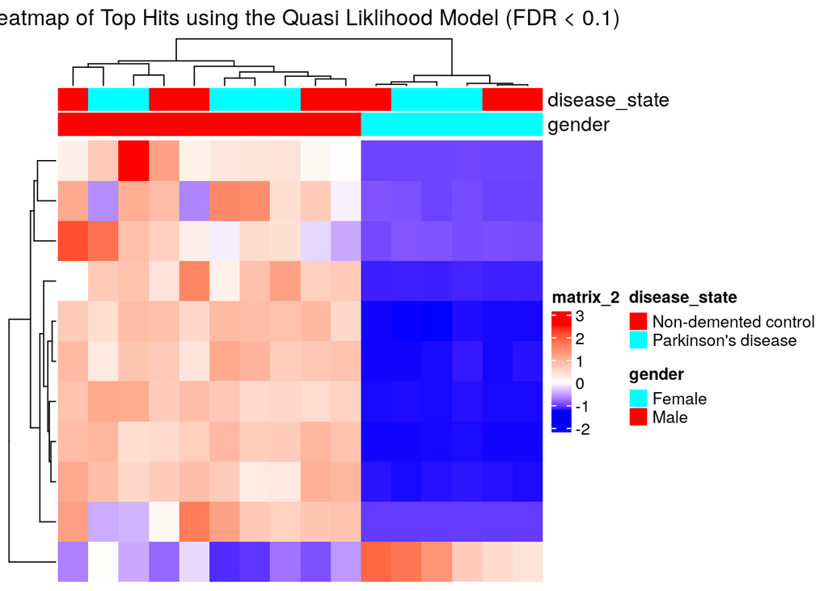

```r
# Select genes pass FDR correction
top_hits_FDR <- rownames(result)[result$FDR<0.1]

# Scale the heatmap matrix
heatmap_matrix_tophits_FDR <- t(
  scale(t(norm_counts[which(rownames(norm_counts)%in% top_hits_FDR),])))

# Set the colour scale
if(min(heatmap_matrix_tophits_FDR) == 0){
  heatmap_col = colorRamp2(c( 0, max(heatmap_matrix_tophits_FDR)), c( "white", "red"))
} else {
  heatmap_col = colorRamp2(c(min(heatmap_matrix_tophits_FDR), 0,
                             max(heatmap_matrix_tophits_FDR)),
                           c("blue", "white", "red"))
}

# Plot the heatmap
FDR_heatmap <- Heatmap(as.matrix(heatmap_matrix_tophits_FDR),
                       top_annotation = ha_pat,
                       cluster_rows = TRUE,
                       cluster_columns = TRUE,
                       show_row_dend = TRUE,
                       show_column_dend = TRUE,
                       col = heatmap_col,
                       show_column_names = FALSE,
                       show_row_names = FALSE,
                       show_heatmap_legend = TRUE,
                       column_title = ("Heatmap of Top Hits using the Quasi Liklihood Model (FDR < 0.1)"))
FDR_heatmap
```

Figure 4: Heatmap of Top Hits using the Quasi Liklihood Model (FDR < 0.1). The heatmap displays expression levels of the top differentially expressed genes across all samples. Each row represents a gene, and each column represents a sample. Gene expression is scaled by row; more vibrant colors indicate higher expression. Annotations for each sample’s condition are shown above the heatmap. Clustering patterns suggest that similar gene expression profiles are associated with each condition, indicating that our conditions may influence these top gene expressions.

From Figure 3 and 4, we can see that in Figure 3, male and female samples are closely clustered with samples of the same sex, but we cannot see too much clustering with samples with different disease state. We selected genes that pass FDR correction and have a closer look in Figure 4. We can see that clustering patterns are more obvious this time, with a clear distinction between male and female, but still less obvious between PD and control. I think that is because the mechanism for male and female patient of PD is very different, possibly involving different disease pathways.

## 3. Thresholded Over-representation Analysis

With our significantly up-regulated and down-regulated set of genes, we will run a thresholded gene set enrichment analysis. Significant genes are selected based on FDR < 0.1 and whether the log fold change is greater than or less than 0.25.

### 3.1 Up-regulated and Down-regulated Genes

First we need to separate genes that are up-regulated and down-regulated.

```r
# Up-regulated genes
upregulated_genes <- rownames(result)[result$FDR < 0.1 & result$logFC > 0.25]

# Down-regulated genes
downregulated_genes <- rownames(result)[result$FDR < 0.1 & result$logFC < -0.25]

# All sig genes
all_significant_genes <- c(upregulated_genes, downregulated_genes)
```

### 3.2 ORA using g:profiler

```r
# gprofiler: upregulated genes
gprofile_up <- gost(query = upregulated_genes,
                    organism = "hsapiens",
                    significant = FALSE,
                    exclude_iea = TRUE,
                    correction_method = "fdr",
                    domain_scope = "annotated",
                    numeric_ns = "",
                    sources = c("GO:BP", "REAC", "WP"))

# gprofiler: downregulated genes
gprofile_down <- gost(query = downregulated_genes,
                      organism = "hsapiens",
                      significant = FALSE,
                      exclude_iea = TRUE,
                      correction_method = "fdr",
                      domain_scope = "annotated",
                      numeric_ns = "",
                      sources = c("GO:BP", "REAC", "WP"))

# gprofiler: all sig genes
gprofile_all <- gost(query = all_significant_genes,
                     organism = "hsapiens",
                     significant = FALSE,
                     exclude_iea = TRUE,
                     correction_method = "fdr",
                     domain_scope = "annotated",
                     numeric_ns = "",
                     sources = c("GO:BP", "REAC", "WP"))
num_genesets_up <- nrow(gprofile_up$result)
num_genesets_down <- nrow(gprofile_down$result)
num_genesets_all <- nrow(gprofile_all$result)
```

Similar to the homework assignment, we filtered out large terms for these genes.

```r
# Filter out large terms for upregulated genes
filtered_gprofile_up <- gprofile_up$result[gprofile_up$result$term_size <= 200, ]

# Filter out large terms for downregulated genes
filtered_gprofile_down <- gprofile_down$result[gprofile_down$result$term_size <= 200, ]

filtered_gprofile <- gprofile_all$result[gprofile_all$result$term_size <= 200, ]

# Check the number of instances in the filtered g:Profiler results
num_filtered_up <- nrow(filtered_gprofile_up)
num_filtered_down <- nrow(filtered_gprofile_down)
num_filtered_all <- nrow(filtered_gprofile)

# Print the numbers for filtered g:Profiler results
print(paste("Number of filtered gene sets for upregulated genes:", num_filtered_up))
```

```
## [1] "Number of filtered gene sets for upregulated genes: 91"
```

```r
print(paste("Number of filtered gene sets for downregulated genes:", num_filtered_down))
```

```
## [1] "Number of filtered gene sets for downregulated genes: 1"
```

```r
print(paste("Number of filtered gene sets for all significant genes:", num_filtered_all))
```

```
## [1] "Number of filtered gene sets for all significant genes: 92"
```

```r
# Create a table for upregulated gene sets
upregulated_table <- kable(filtered_gprofile_up,
                           caption = "Enriched Gene Sets for Upregulated Genes",
                           row.names = FALSE)

# Create a table for downregulated gene sets
downregulated_table <- kable(filtered_gprofile_down,
                             caption = "Enriched Gene Sets for Downregulated Genes",
                             row.names = FALSE)

# Create a table for all gene sets
all_table <- kable(filtered_gprofile,
                   caption = "Enriched Gene Sets for All Sig Genes",
                   row.names = FALSE)
```

**Tables**:

The tables below present the enriched gene sets for upregulated and downregulated genes after filtering to exclude overly large gene sets:

```r
upregulated_table
```

Enriched Gene Sets for Upregulated Genes

| query | significant | p_value | term_size | query_size | intersection_size | precision | recall | term_id | source | term_name | effective_domain_size | source_order | parents |
| --- | --- | --- | --- | --- | --- | --- | --- | --- | --- | --- | --- | --- | --- |
| query_1 | FALSE | 0.2076519 | 11 | 10 | 1 | 0.1000000 | 0.0909091 | GO:0042989 | GO:BP | sequestering of actin monomers | 16178 | 10822 | GO:00308…. |
| query_1 | FALSE | 0.2076519 | 8 | 10 | 1 | 0.1000000 | 0.1250000 | GO:0097104 | GO:BP | postsynaptic membrane assembly | 16178 | 19032 | GO:00019…. |
| query_1 | FALSE | 0.2076519 | 11 | 10 | 1 | 0.1000000 | 0.0909091 | GO:0097090 | GO:BP | presynaptic membrane organization | 16178 | 19021 | GO:00508…. |
| query_1 | FALSE | 0.2076519 | 10 | 10 | 1 | 0.1000000 | 0.1000000 | GO:0097105 | GO:BP | presynaptic membrane assembly | 16178 | 19033 | GO:00717…. |
| query_1 | FALSE | 0.2180181 | 13 | 10 | 1 | 0.1000000 | 0.0769231 | GO:0071625 | GO:BP | vocalization behavior | 16178 | 17307 | GO:0007610 |
| query_1 | FALSE | 0.2193597 | 16 | 10 | 1 | 0.1000000 | 0.0625000 | GO:0099068 | GO:BP | postsynapse assembly | 16178 | 19578 | GO:00074…. |
| query_1 | FALSE | 0.2193597 | 15 | 10 | 1 | 0.1000000 | 0.0666667 | GO:0007158 | GO:BP | neuron cell-cell adhesion | 16178 | 2753 | GO:0098609 |
| query_1 | FALSE | 0.2287859 | 31 | 10 | 1 | 0.1000000 | 0.0322581 | GO:0099054 | GO:BP | presynapse assembly | 16178 | 19577 | GO:00074…. |
| query_1 | FALSE | 0.2287859 | 30 | 10 | 1 | 0.1000000 | 0.0333333 | GO:0060765 | GO:BP | regulation of androgen receptor signaling pathway | 16178 | 15406 | GO:00305…. |
| query_1 | FALSE | 0.2287859 | 31 | 10 | 1 | 0.1000000 | 0.0322581 | GO:0051703 | GO:BP | biological process involved in intraspecies interaction between organisms | 16178 | 14358 | GO:0008150 |
| query_1 | FALSE | 0.2287859 | 32 | 10 | 1 | 0.1000000 | 0.0312500 | GO:0099172 | GO:BP | presynapse organization | 16178 | 19631 | GO:00160…. |
| query_1 | FALSE | 0.2287859 | 29 | 10 | 1 | 0.1000000 | 0.0344828 | GO:0035176 | GO:BP | social behavior | 16178 | 9172 | GO:00076…. |
| query_1 | FALSE | 0.2287859 | 22 | 10 | 1 | 0.1000000 | 0.0454545 | GO:0001941 | GO:BP | postsynaptic membrane organization | 16178 | 558 | GO:00610…. |
| query_1 | FALSE | 0.2836182 | 46 | 10 | 1 | 0.1000000 | 0.0217391 | GO:0030521 | GO:BP | androgen receptor signaling pathway | 16178 | 7072 | GO:0030518 |
| query_1 | FALSE | 0.2836182 | 59 | 10 | 1 | 0.1000000 | 0.0169492 | GO:0036465 | GO:BP | synaptic vesicle recycling | 16178 | 9945 | GO:00068…. |
| query_1 | FALSE | 0.2836182 | 49 | 10 | 1 | 0.1000000 | 0.0204082 | GO:0048488 | GO:BP | synaptic vesicle endocytosis | 16178 | 13206 | GO:00364…. |
| query_1 | FALSE | 0.2836182 | 57 | 10 | 1 | 0.1000000 | 0.0175439 | GO:0032272 | GO:BP | negative regulation of protein polymerization | 16178 | 7725 | GO:00313…. |
| query_1 | FALSE | 0.2836182 | 58 | 10 | 1 | 0.1000000 | 0.0172414 | GO:0044091 | GO:BP | membrane biogenesis | 16178 | 11276 | GO:0044085 |
| query_1 | FALSE | 0.2836182 | 57 | 10 | 1 | 0.1000000 | 0.0175439 | GO:0032507 | GO:BP | maintenance of protein location in cell | 16178 | 7888 | GO:00451…. |
| query_1 | FALSE | 0.2836182 | 53 | 10 | 1 | 0.1000000 | 0.0188679 | GO:0007612 | GO:BP | learning | 16178 | 3103 | GO:0007611 |
| query_1 | FALSE | 0.2836182 | 54 | 10 | 1 | 0.1000000 | 0.0185185 | GO:0071709 | GO:BP | membrane assembly | 16178 | 17379 | GO:00226…. |
| query_1 | FALSE | 0.2836182 | 49 | 10 | 1 | 0.1000000 | 0.0204082 | GO:0140238 | GO:BP | presynaptic endocytosis | 16178 | 20274 | GO:00068…. |
| query_1 | FALSE | 0.2836182 | 45 | 10 | 1 | 0.1000000 | 0.0222222 | GO:0030837 | GO:BP | negative regulation of actin filament polymerization | 16178 | 7159 | GO:00300…. |
| query_1 | FALSE | 0.2852800 | 62 | 10 | 1 | 0.1000000 | 0.0161290 | GO:0033143 | GO:BP | regulation of intracellular steroid hormone receptor signaling pathway | 16178 | 8337 | GO:00099…. |
| query_1 | FALSE | 0.3195689 | 110 | 10 | 1 | 0.1000000 | 0.0090909 | GO:0043401 | GO:BP | steroid hormone mediated signaling pathway | 16178 | 11025 | GO:00097…. |
| query_1 | FALSE | 0.3195689 | 121 | 10 | 1 | 0.1000000 | 0.0082645 | GO:0099003 | GO:BP | vesicle-mediated transport in synapse | 16178 | 19549 | GO:0016192 |
| query_1 | FALSE | 0.3195689 | 113 | 10 | 1 | 0.1000000 | 0.0088496 | GO:0006413 | GO:BP | translational initiation | 16178 | 2195 | GO:00064…. |
| query_1 | FALSE | 0.3195689 | 114 | 10 | 1 | 0.1000000 | 0.0087719 | GO:0031333 | GO:BP | negative regulation of protein-containing complex assembly | 16178 | 7381 | GO:00432…. |
| query_1 | FALSE | 0.3195689 | 82 | 10 | 1 | 0.1000000 | 0.0121951 | GO:0045185 | GO:BP | maintenance of protein location | 16178 | 11703 | GO:00081…. |
| query_1 | FALSE | 0.3195689 | 98 | 10 | 1 | 0.1000000 | 0.0102041 | GO:0099173 | GO:BP | postsynapse organization | 16178 | 19632 | GO:00160…. |

[output cut: 61 more lines]

```r
downregulated_table
```

Enriched Gene Sets for Downregulated Genes

| query | significant | p_value | term_size | query_size | intersection_size | precision | recall | term_id | source | term_name | effective_domain_size | source_order | parents |
| --- | --- | --- | --- | --- | --- | --- | --- | --- | --- | --- | --- | --- | --- |
| query_1 | TRUE | 0.0048274 | 20 | 1 | 1 | 1 | 0.05 | WP:WP3657 | WP | Hematopoietic stem cell gene regulation by GABP alpha beta complex | 8286 | 250 | WP:000000 |

```r
all_table
```

Enriched Gene Sets for All Sig Genes

| query | significant | p_value | term_size | query_size | intersection_size | precision | recall | term_id | source | term_name | effective_domain_size | source_order | parents |
| --- | --- | --- | --- | --- | --- | --- | --- | --- | --- | --- | --- | --- | --- |
| query_1 | FALSE | 0.2397311 | 13 | 11 | 1 | 0.0909091 | 0.0769231 | GO:0071625 | GO:BP | vocalization behavior | 16178 | 17307 | GO:0007610 |
| query_1 | FALSE | 0.2397311 | 11 | 11 | 1 | 0.0909091 | 0.0909091 | GO:0042989 | GO:BP | sequestering of actin monomers | 16178 | 10822 | GO:00308…. |
| query_1 | FALSE | 0.2397311 | 11 | 11 | 1 | 0.0909091 | 0.0909091 | GO:0097090 | GO:BP | presynaptic membrane organization | 16178 | 19021 | GO:00508…. |
| query_1 | FALSE | 0.2397311 | 10 | 11 | 1 | 0.0909091 | 0.1000000 | GO:0097105 | GO:BP | presynaptic membrane assembly | 16178 | 19033 | GO:00717…. |
| query_1 | FALSE | 0.2397311 | 8 | 11 | 1 | 0.0909091 | 0.1250000 | GO:0097104 | GO:BP | postsynaptic membrane assembly | 16178 | 19032 | GO:00019…. |
| query_1 | FALSE | 0.2411839 | 16 | 11 | 1 | 0.0909091 | 0.0625000 | GO:0099068 | GO:BP | postsynapse assembly | 16178 | 19578 | GO:00074…. |
| query_1 | FALSE | 0.2411839 | 15 | 11 | 1 | 0.0909091 | 0.0666667 | GO:0007158 | GO:BP | neuron cell-cell adhesion | 16178 | 2753 | GO:0098609 |
| query_1 | FALSE | 0.2639952 | 31 | 11 | 1 | 0.0909091 | 0.0322581 | GO:0099054 | GO:BP | presynapse assembly | 16178 | 19577 | GO:00074…. |
| query_1 | FALSE | 0.2639952 | 30 | 11 | 1 | 0.0909091 | 0.0333333 | GO:0060765 | GO:BP | regulation of androgen receptor signaling pathway | 16178 | 15406 | GO:00305…. |
| query_1 | FALSE | 0.2639952 | 31 | 11 | 1 | 0.0909091 | 0.0322581 | GO:0051703 | GO:BP | biological process involved in intraspecies interaction between organisms | 16178 | 14358 | GO:0008150 |
| query_1 | FALSE | 0.2639952 | 32 | 11 | 1 | 0.0909091 | 0.0312500 | GO:0099172 | GO:BP | presynapse organization | 16178 | 19631 | GO:00160…. |
| query_1 | FALSE | 0.2639952 | 29 | 11 | 1 | 0.0909091 | 0.0344828 | GO:0035176 | GO:BP | social behavior | 16178 | 9172 | GO:00076…. |
| query_1 | FALSE | 0.2639952 | 22 | 11 | 1 | 0.0909091 | 0.0454545 | GO:0001941 | GO:BP | postsynaptic membrane organization | 16178 | 558 | GO:00610…. |
| query_1 | FALSE | 0.3114235 | 59 | 11 | 1 | 0.0909091 | 0.0169492 | GO:0036465 | GO:BP | synaptic vesicle recycling | 16178 | 9945 | GO:00068…. |
| query_1 | FALSE | 0.3114235 | 49 | 11 | 1 | 0.0909091 | 0.0204082 | GO:0048488 | GO:BP | synaptic vesicle endocytosis | 16178 | 13206 | GO:00364…. |
| query_1 | FALSE | 0.3114235 | 57 | 11 | 1 | 0.0909091 | 0.0175439 | GO:0032507 | GO:BP | maintenance of protein location in cell | 16178 | 7888 | GO:00451…. |
| query_1 | FALSE | 0.3114235 | 45 | 11 | 1 | 0.0909091 | 0.0222222 | GO:0030837 | GO:BP | negative regulation of actin filament polymerization | 16178 | 7159 | GO:00300…. |
| query_1 | FALSE | 0.3114235 | 58 | 11 | 1 | 0.0909091 | 0.0172414 | GO:0044091 | GO:BP | membrane biogenesis | 16178 | 11276 | GO:0044085 |
| query_1 | FALSE | 0.3114235 | 46 | 11 | 1 | 0.0909091 | 0.0217391 | GO:0030521 | GO:BP | androgen receptor signaling pathway | 16178 | 7072 | GO:0030518 |
| query_1 | FALSE | 0.3114235 | 57 | 11 | 1 | 0.0909091 | 0.0175439 | GO:0032272 | GO:BP | negative regulation of protein polymerization | 16178 | 7725 | GO:00313…. |
| query_1 | FALSE | 0.3114235 | 53 | 11 | 1 | 0.0909091 | 0.0188679 | GO:0007612 | GO:BP | learning | 16178 | 3103 | GO:0007611 |
| query_1 | FALSE | 0.3114235 | 54 | 11 | 1 | 0.0909091 | 0.0185185 | GO:0071709 | GO:BP | membrane assembly | 16178 | 17379 | GO:00226…. |
| query_1 | FALSE | 0.3114235 | 49 | 11 | 1 | 0.0909091 | 0.0204082 | GO:0140238 | GO:BP | presynaptic endocytosis | 16178 | 20274 | GO:00068…. |
| query_1 | FALSE | 0.3167390 | 62 | 11 | 1 | 0.0909091 | 0.0161290 | GO:0033143 | GO:BP | regulation of intracellular steroid hormone receptor signaling pathway | 16178 | 8337 | GO:00099…. |
| query_1 | FALSE | 0.3561882 | 114 | 11 | 1 | 0.0909091 | 0.0087719 | GO:0031333 | GO:BP | negative regulation of protein-containing complex assembly | 16178 | 7381 | GO:00432…. |
| query_1 | FALSE | 0.3561882 | 121 | 11 | 1 | 0.0909091 | 0.0082645 | GO:0099003 | GO:BP | vesicle-mediated transport in synapse | 16178 | 19549 | GO:0016192 |
| query_1 | FALSE | 0.3561882 | 110 | 11 | 1 | 0.0909091 | 0.0090909 | GO:0043401 | GO:BP | steroid hormone mediated signaling pathway | 16178 | 11025 | GO:00097…. |
| query_1 | FALSE | 0.3561882 | 113 | 11 | 1 | 0.0909091 | 0.0088496 | GO:0006413 | GO:BP | translational initiation | 16178 | 2195 | GO:00064…. |
| query_1 | FALSE | 0.3561882 | 106 | 11 | 1 | 0.0909091 | 0.0094340 | GO:0070646 | GO:BP | protein modification by small protein removal | 16178 | 16726 | GO:0070647 |
| query_1 | FALSE | 0.3561882 | 127 | 11 | 1 | 0.0909091 | 0.0078740 | GO:0051494 | GO:BP | negative regulation of cytoskeleton organization | 16178 | 14204 | GO:00070…. |

[output cut: 62 more lines]

### 3.3 Gene Set Enrichment Analysis Discussion

**Methodology**: We selected the `g:Profiler` tool for our over-representation analysis due to its comprehensive collection of annotation data and its ease of integration within the R environment. We have also done a homework using `g:Profiler` so it is very convenient to integrate into our notebook.

**Annotation Data**: The analysis included gene ontology (GO) annotations for biological processes (GO:BP), Reactome (REAC), and WikiPathways (WP) to ensure a broad representation of potential pathways and processes.

**Version of Annotation**: The analysis was conducted using the `gprofiler2: Interface to the 'g:Profiler' Toolset` version available on 2024-02-23, ensuring up-to-date annotations were used.

**Comparison of Results**: We can see that there is a large overlap betweeen pathways in up-regulated gens and that in the entire list of genes. Most of the genes are involved in biological processes (like pre and post synaptic assembly) and reactome (like HDMs demethylate histones). Since there is only one term in `Enriched Gene Sets for Downregulated Genes`, the intepretation is inconclusisve, but we can see that pathways of down-regulated genes are very different comparing to that of up-regualted genes.

## 4. Intepretation

Here are the top hits from my result:

```r
top_hits_FDR
```

```
##  [1] "RPS4Y1"  "EIF1AY"  "USP9Y"   "ZFY"     "NLGN4Y"  "KDM5D"   "DDX3Y"
##  [8] "UTY"     "TMSB4Y"  "PCDH11Y" "ZFX"
```

I found another paper<sup>3</sup> focusing on genetic sex differences in early human neuronal development which a substantial context for understanding the role of genes in Parkinson’s disease (PD).

My result include genes such as “RPS4Y1,” “EIF1AY,” “USP9Y,” “ZFY,” “NLGN4Y,” “KDM5D,” “DDX3Y,” “UTY,” “TMSB4Y,” “PCDH11Y,” and “ZFX,” aligns with the understanding that sex chromosome genes play a crucial role in neuronal development and potentially in the pathogenesis of neurodegenerative diseases.

RPS4Y1 and EIF1AY are located on the Y chromosome, potentially implicating their unique contributions to male-specific brain development and functions. Their expression in the brain could influence susceptibility to or protection against PD in males.

USP9Y and DDX3Y are also Y-linked genes known for their roles in spermatogenesis but may have broader implications in gene regulation and cellular stress responses, which are crucial in neurodegenerative diseases.

ZFY and KDM5D contribute to gene expression regulation and chromatin remodeling, respectively, processes that are vital for maintaining neuronal health and function.

NLGN4Y is involved in synapse formation and function, suggesting its potential impact on neuronal communication, which is often disrupted in PD.

UTY, TMSB4Y, and PCDH11Y play roles in transcription regulation, actin cytoskeleton organization, and cell adhesion, respectively, further implicating the complex contributions of Y chromosome genes to brain physiology and potentially to PD pathology.

Insights from Pottmeier’s dissertation reinforce the importance of considering sex as a biological variable in PD research. The expression of these Y-linked genes in early neuronal development suggests that they could have lifelong impacts on brain structure, function, and disease susceptibility. Future investigation could work on understanding their specific roles and leading to targeted interventions that consider genetic sex differences.

## 5. References

Please note that all package references are included in the `a2References.bib`.

1.

Tranchevent, L.-C., Halder, R. & Glaab, E. [Systems level analysis of sex-dependent gene expression changes in parkinson’s disease](https://doi.org/10.1038/s41531-023-00446-8). *NPJ Parkinson’s Disease* **9**, 8 (2023).

2.

Sun, A. G. *et al.* Identifying distinct candidate genes for early parkinson’s disease by analysis of gene expression in whole blood. *Neuro Endocrinology Letters* **35**, 398–404 (2014).

3.

Pottmeier, P. Genetic sex differences in early human neuronal development: An investigation in embryo tissue and embryonic stem cells. vol. 2263 84 (Acta Universitatis Upsaliensis, Uppsala, 2023).